# Variance partition of isoform expression in a split-plot design

J. Ignacio Lucas Lledó

9/1/2020

# Introduction

The EdgeR package (Robinson, McCarthy, and Smyth 2010) has the advantage of modelling count data, instead of relative expression levels. It offers some capacity to fit complex models (McCarthy, Chen, and Smyth 2012). But it does not include random effects. The experiment was a split-plot design, which requires a mixed model with the random effect of the original population of origin in order to properly account for the correlation of expression levels in sub-populations of the same origin.

The `variancePartition` package (Hoffman and Schadt 2016) fits mixed models to the expression data of every isoform in the dataset. It also includes the `dream()` function [Hoffman2020] to test for differential expression under this framework. It does require the expression level to be normalized, though.

```r
library(variancePartition)
library(edgeR)
library(BiocParallel)
library(cp4p)
COUNTS_FILE <- '../2019-03-29/isoforms.PostCount.txt'
NUM_THREADS <- 40  # Number of cores for parallelization.
TAG <- 'isoforms'
```

# Variance partition

When fitting the model to every isoform’s expression profile, information from all isoforms contribute to every fit. The shared information helps determine the dispersion of every measure. Counts are heteroscedastic: their variance depend on their mean. The exact mean-variance relationship may be complex, but it can be learned from the data. The `limma` package (Ritchie et al. 2015) uses the `voom()` function (Law et al. 2014) to 1) transform count data to log2-counts per million, and to estimate the mean-variance relationship. Once that relationship is estimated, every expression level is assigned a *weight*: the inverse of its predicted variance. This weights account for the heteroscedasticity and are used afterwards in fitting the model and in testing for differential expression.

Curiously, though, a model needs to be fit first, for every isoform. The residual standard deviation and the average isoform expression level of that fit is one point in the scatterplot where the mean-variance relationship becomes apparent. When fitting these isoform-wise linear models, `voom()` does not consider random errors, but `voomWithDreamWeights()` does.

```r
counts <- as.matrix(read.table(COUNTS_FILE, row.names=1, header=TRUE))

## Filtering
# An isoform is expressed if it has at least 5 reads, which in terms of CPM in the smallest
# library is equal to `threshold`. Only isoforms expressed in at least 4 samples are retained.
threshold <- 5 / (min(colSums(counts)) / 1000000)
keep <- rowSums(cpm(counts) > threshold) >= 4
geneExpr <- DGEList(counts[keep,])
geneExpr <- calcNormFactors(geneExpr)
numOfTags <- dim(geneExpr)[1]

## Metadata
metadata <- data.frame(row.names = c("X1A_S8", "X1C_S1", "X2A_S7", "X2C_S5",
                                  "X3A_S9", "X3C_S11", "X4A_S6", "X4C_S12",
                                  "X5A_S2", "X5C_S4", "X6A_S3", "X6C_S10"),
                       regime = c(1, 1, 1, 1, 0, 0 , 1, 1, 0, 0, 0, 0),
                       regimeChar = c("random", "random", "random", "random",
                                  "regular", "regular", "random", "random",
                                  "regular", "regular", "regular", "regular"),
                       population = c("1", "1", "2", "2", "3", "3",
                                      "4", "4", "5", "5", "6", "6"),
                       treatment = rep(c(0, 1), 6),
                       treatmentChar = rep(c("hatch", "diapause"), 6))

## Model (includes interaction term)
form <- ~ regime + treatment + regime:treatment + (1|population)
```

The `variancePartition` package requires all categorical variables to be random effects. This is a way to prevent bias when estimating the variance component of categorical variables with many levels. However, the `dream()` function seems to require the variable to be tested be a fixed effect. To get out of this catch22, I dummy-code regime and treatment as numeric variables with values 0 and 1.

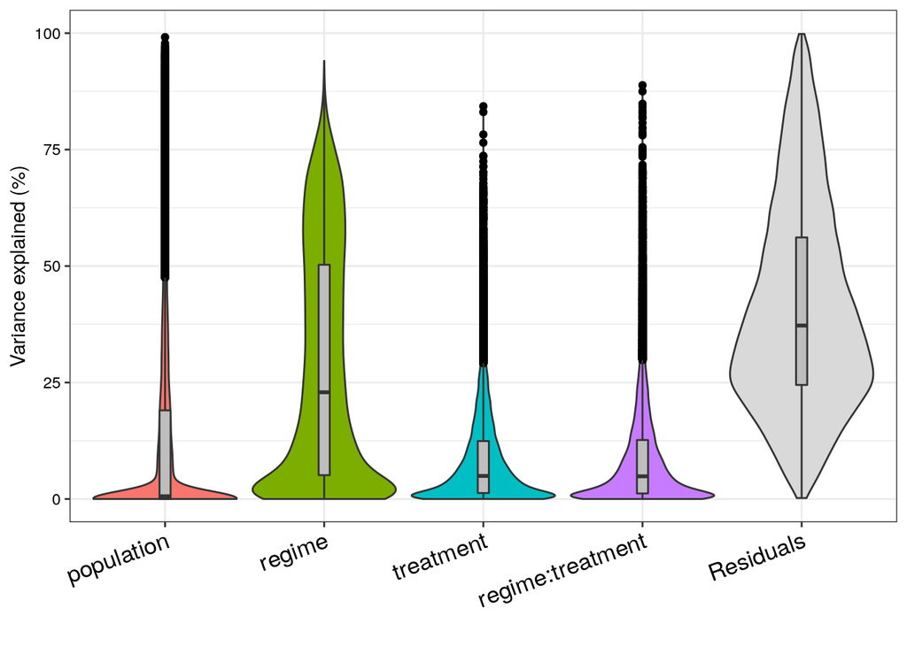

```r
## Parallelization
param = SnowParam(NUM_THREADS, "SOCK")
register(param)

## Weights
vobjDream <- voomWithDreamWeights(geneExpr, form, metadata)

## Variance partition
varPart <- fitExtractVarPartModel(vobjDream, form, metadata)
plotVarPart(varPart)
```

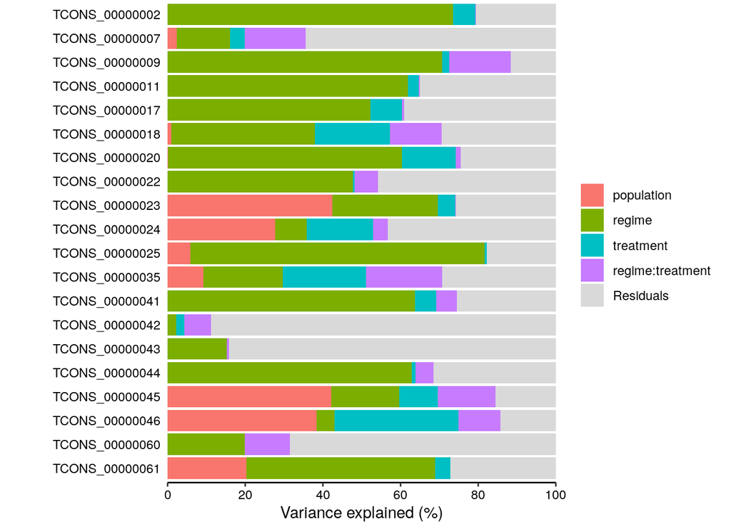

```r
plotPercentBars(varPart[1:20,])
```

Recall that the partition of variance shows relative amounts of variance explained by individual predictors, irrespectively of the absolute amount of variation. Thus, isoforms for which a large fraction of their expression variance is explained by the selective regime do not necessarily have large fold change values. Let’s take a look at the stratified expression level of the isoform with largest fraction of variance explained by regime:

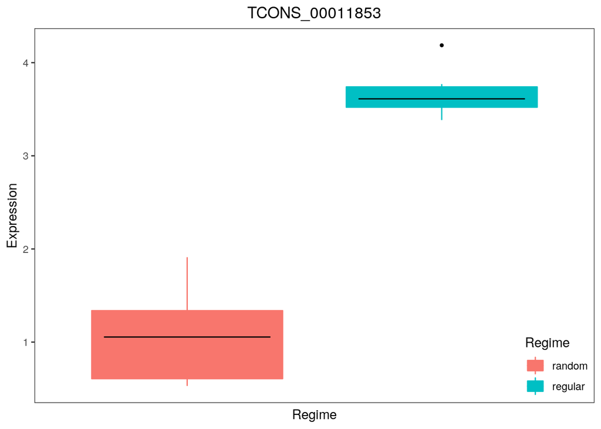

```r
i <- which.max(varPart$regime)

# Expression level is log2 counts per million.
GE <- data.frame(Expression = vobjDream$E[i,], Regime = metadata$regimeChar)
plotStratify(Expression ~ Regime, GE, main = rownames(vobjDream$E)[i])
```

```r
rm(GE)
```

Below I write the lists of isoforms with their fraction of expression variance explained by either selective regime or hatching condition. The isoforms are ordered from the one the expression of which is most affected by that variable to the one that is least affected. Note that among the top isoforms there will be both positive and negatively affected isoforms.

```r
# Ordered by regime effect:
head(varPart[order(varPart$regime, decreasing = TRUE),])
```

```
##                  population    regime    treatment regime:treatment  Residuals
## TCONS_00011853 0.0081465697 0.9403626 4.567918e-03     4.049036e-05 0.04688239
## TCONS_00021223 0.0291975236 0.9401104 5.620156e-03     3.457643e-03 0.02161430
## TCONS_00040399 0.0000000000 0.9387069 3.063143e-05     2.680062e-03 0.05858237
## TCONS_00038865 0.0006466251 0.9270017 5.153335e-04     5.480510e-03 0.06635580
## TCONS_00037264 0.0000000000 0.9234706 2.297775e-02     6.996652e-03 0.04655501
## TCONS_00011535 0.0142612642 0.9223187 1.314474e-02     6.588769e-04 0.04961645
```

```r
write.table(varPart[order(varPart$regime, decreasing = TRUE), 'regime', drop=FALSE],
            file = paste(TAG, '/regime_variance.txt', sep=''), quote=FALSE,
            row.names = TRUE, col.names = TRUE)

# Order by hatching condition effect:
head(varPart[order(varPart$treatment, decreasing=TRUE),])
```

```
##                  population       regime treatment regime:treatment  Residuals
## TCONS_00075636 2.074207e-21 2.238338e-03 0.8430845      0.015679345 0.13899778
## TCONS_00005715 1.659293e-02 1.891674e-02 0.8306170      0.002401520 0.13147180
## TCONS_00069526 0.000000e+00 1.356985e-03 0.7824304      0.015172945 0.20103969
## TCONS_00017516 2.788176e-02 1.227073e-01 0.7648633      0.001332431 0.08321521
## TCONS_00009155 0.000000e+00 2.694792e-05 0.7366596      0.009292916 0.25402056
## TCONS_00031938 4.027828e-02 2.924518e-02 0.7355954      0.077769861 0.11711130
```

```r
write.table(varPart[order(varPart$treatment, decreasing = TRUE), 'treatment', drop=FALSE],
            file = paste(TAG, '/hatching_variance.txt', sep=''), quote = FALSE,
            row.names = TRUE, col.names = TRUE)
```